# From Large Spatiotemporal Data to Urban Insights

### What We’ll Do Today

Across IoT systems, remote sensing, urban platforms, simulation pipelines, and administrative databases, we now have access to huge volumes of spatial and temporal data. Much of it is useful. Some of it is noise. But in either case, the practical challenge is the same:

> how do we turn large raw datasets into something usable for analysis, modelling, and digital twins — without wasting computation, memory, and time?

The specific example in this notebook uses **climate data**, because that is my own area of expertise. But the workflow logic is much broader.

You could swap this dataset for:

- air quality data
- mobility traces
- energy consumption records
- satellite imagery products
- sensor networks
- population or land-use grids

The **source changes**, the **format changes**, sometimes even the **libraries change** — but the core ideas remain the same:

- inspect data carefully before processing
- avoid unnecessary work
- aggregate only what you need
- choose storage formats that support downstream analysis
- write code that scales better as data grows

Digital twins depend on data that is not only detailed, but also **usable**.

In practice, raw data rarely arrives in the form needed for modelling or decision support.  
It often needs to be:

- cleaned
- subsetted
- aggregated
- joined to meaningful spatial units
- converted into efficient analysis-ready formats

That preparation step is often where most of the real work happens.

If we had unlimited computing resources, one solution would be simple: throw more hardware at the problem.

But most of us do not work with effectively unlimited compute budgets.

So in practice there are two main strategies:

1. use tools designed for larger-scale computation, such as **Dask** or **PySpark**
2. write **more efficient code** so we do less unnecessary work in the first place

In this notebook, we focus mainly on the second strategy: efficient data handling and transformation.  
If time permits, the second notebook looks at approaches such as **vectorisation** and **Dask**.

### Today’s Example Workflow

To make these ideas concrete, we will work with a real spatiotemporal raster dataset and transform it into a form that is more useful for urban analysis.

**Pipeline:**

```
Raw gridded data → inspect structure → spatially aggregate to urban units → store efficiently → explore for analysis
```

The example here uses gridded climate data for London, which we will aggregate to borough-level units.

The aim is not only to get a final dataset, but to show how to think about:

- data volume
- memory use
- repeated operations
- file formats
- spatial aggregation
- analysis-ready outputs

### The Example Data

For this workshop, we use a gridded precipitation indicator dataset for London together with London borough boundaries.

The climate dataset is useful here because it has several characteristics that are common in many urban and environmental workflows:

- it is **spatial**
- it is **temporal**
- it is stored in a scientific array format
- it must be transformed before it becomes useful for city-level analysis

So although the example is climate-focused, the same workflow pattern applies far beyond climate.

The main lesson is not “how to work with precipitation data.”  
The main lesson is **how to work efficiently with large spatiotemporal data.**

### Context on the Source Data

The example dataset comes from the **Copernicus Climate Data Store**, using a city-scale extreme precipitation product provided as gridded data.

For the workshop, the data has already been prepared and downloaded, so we can focus on processing rather than acquisition.

Each file is a NetCDF (`.nc`) containing gridded daily values over time.

> In a real workflow, acquisition and data organisation are also important parts of the pipeline. Here, we start from the point where raw files are already available locally so we can concentrate on efficient processing and transformation.

### 1.3 Environment Setup

```python
# Core libraries
import pandas as pd
import geopandas as gpd
import xarray as xr
import numpy as np

# Spatial aggregation
import xagg

# Visualisation
import matplotlib.pyplot as plt
import seaborn as sns
import plotly.express as px

# Workflow utilities
from tqdm.notebook import tqdm  # progress bars for notebooks
import gc                       # garbage collection for memory management
import os
import time
from pathlib import Path

# Display settings
pd.set_option('display.max_columns', None)
pd.set_option('display.float_format', '{:.4f}'.format)
```

```python
# Define paths — adjust these to match your folder structure
DATA_DIR = Path("london_data/raw_nc")       # folder with ldn_tp_YYYY.nc files
OUTPUT_DIR = Path("london_data/parquet")     # where we'll save processed parquet files
GEO_DIR = Path("london_data/geo")           # borough boundaries

OUTPUT_DIR.mkdir(parents=True, exist_ok=True)

YEARS = range(2000, 2019)  # 2000 to 2018 inclusive
```

## Loading & Exploring Gridded Data with xarray

### What Is xarray?

If you work primarily with tabular or vector data, you may not have encountered **xarray** before. The simplest way to think about it:

> **xarray is like pandas, but for multi-dimensional data.**

A pandas DataFrame is 2D — rows and columns. But gridded climate data is inherently **3D or higher**: it has a latitude axis, a longitude axis, and a time axis. Each cell in that 3D cube holds a measurement.

```
pandas DataFrame:          xarray Dataset:
┌──────────────────┐       ┌─────────────────────────┐
│  rows × columns  │       │  lat × lon × time       │
│  (2D table)      │       │  (3D+ labelled cube)    │
└──────────────────┘       └─────────────────────────┘
```

The key advantage: xarray lets you **select, slice, and aggregate using dimension names and coordinate labels** (e.g., `ds.sel(time='2018-07-15')`) rather than integer indices. It also integrates with NetCDF, the standard file format for climate and earth science data.

**Two core objects:**

- `xr.DataArray` — a single labelled N-dimensional array (like one variable: e.g., precipitation)
- `xr.Dataset` — a collection of DataArrays sharing the same dimensions (like a NetCDF file with multiple variables)

### Loading a Single Year

```python
# Load one year to explore the structure
sample_file = DATA_DIR / "ldn_tp_2018.nc"
ds = xr.open_dataset(sample_file)
ds
```

```
<xarray.Dataset> Size: 6MB
Dimensions:    (rlon: 41, rlat: 52, time: 365)
Coordinates:
  * rlon       (rlon) float64 328B 2.018 2.038 2.058 2.078 ... 2.778 2.798 2.818
  * rlat       (rlat) float64 416B -2.944 -2.924 -2.904 ... -1.964 -1.944 -1.924
    longitude  (rlat, rlon) float64 17kB ...
    latitude   (rlat, rlon) float64 17kB ...
  * time       (time) datetime64[ns] 3kB 2018-01-01 2018-01-02 ... 2018-12-31
Data variables:
    nrr95p     (time, rlat, rlon) float64 6MB ...
Attributes:
    institution:  Fondazione Centro Euro-Mediterraneo sui Cambiamenti Climati...
    experiment:   ERA5-2km i.e., cclm-sp_2.4_terra_urb_2.3.1 simulation (0.02...
    references:   http//www.clm-community.eu, http://www.cmcc.it
    Conventions:  CF-1.6
    contacts:     copernicus-support@ecmwf.int
    contract:     C3S_430 Sectoral Information System to support Disaster Ris...
    title:        Extreme precipitation indicators for Europe and European ci...
    author:       Fondazione Centro Euro-Mediterraneo sui Cambiamenti Climati...
    version:      version 1.0
```

**What are we looking at?**

- **Dimensions:** The axes of our data cube (e.g., `time`, `rlat`, `rlon` — the rotated lat/lon grid)
- **Coordinates:** The labels along each dimension (actual lat/lon values, dates)
- **Data variables:** The actual measurements (e.g., `nrr95p` — our extreme precipitation indicator)
- **Attributes:** Metadata about the dataset (source, units, description)

### Basic xarray Operations

xarray lets us select, slice, and aggregate data using **dimension names and coordinate labels** rather than integer indices. This makes code much more readable and less error-prone.

```python
# Select a single day
one_day = ds['nrr95p'].sel(time='2018-07-15')
print(f"Shape of one day's data: {one_day.shape}")
print(f"Min: {float(one_day.min()):.4f}, Max: {float(one_day.max()):.4f}, Mean: {float(one_day.mean()):.4f}")
```

```
Shape of one day's data: (52, 41)
Min: 0.0000, Max: 0.0109, Mean: 0.0004
```

### From xarray to Tabular Data (and When You Should — and Shouldn't)

For many downstream tasks (merging with census data, statistical modelling, machine learning), you need tabular data. xarray can convert to pandas DataFrames — but there's an important caveat.

> ⚠️ **Performance Warning:** xarray is optimised for operating on large multi-dimensional arrays *in its native format*. Converting to a pandas DataFrame "melts" the entire grid into rows, which can **severely degrade performance** and use far more memory. For a file with millions of grid cells × hundreds of time steps, the conversion itself can take a very long time and the resulting DataFrame may not even fit in memory.

> **Rule of thumb:** Do as much work as possible in xarray (selection, aggregation, masking) *before* converting to pandas. Only convert when you genuinely need tabular operations.

For our dataset this conversion is fine (the files are manageable), but keep this in mind when you scale up to larger grids or longer time series.

```python
# Convert to DataFrame — this "melts" the 3D grid into rows
df_sample = ds.to_dataframe().reset_index()
print(f"Shape: {df_sample.shape}")
print(f"Memory usage: {df_sample.memory_usage(deep=True).sum() / 1e6:.1f} MB")
df_sample.head()
```

```
Shape: (778180, 6)
Memory usage: 37.4 MB
```

|  | rlon | rlat | time | longitude | latitude | nrr95p |
| --- | --- | --- | --- | --- | --- | --- |
| 0 | 2.0183 | -2.9445 | 2018-01-01 | -0.7954 | 51.0098 | NaN |
| 1 | 2.0183 | -2.9445 | 2018-01-02 | -0.7954 | 51.0098 | NaN |
| 2 | 2.0183 | -2.9445 | 2018-01-03 | -0.7954 | 51.0098 | NaN |
| 3 | 2.0183 | -2.9445 | 2018-01-04 | -0.7954 | 51.0098 | NaN |
| 4 | 2.0183 | -2.9445 | 2018-01-05 | -0.7954 | 51.0098 | NaN |

```python
# Drop NaN in pandas — removes grid cells outside the data coverage
print(f"Rows before dropping NaN: {len(df_sample):,}")
df_sample = df_sample.dropna(subset=['nrr95p'])
print(f"Rows after dropping NaN:  {len(df_sample):,}")
```

```
Rows before dropping NaN: 778,180
Rows after dropping NaN:  19,345
```

### Quick Spatial Visualisation with GeoPandas

Let's see where our grid points fall relative to London's boroughs.

```python
# Create a GeoDataFrame of mean values per grid point (for plotting)
grid_means = df_sample.groupby(['latitude', 'longitude'])['nrr95p'].mean().reset_index()
grid_gdf = gpd.GeoDataFrame(
    grid_means,
    geometry=gpd.points_from_xy(grid_means.longitude, grid_means.latitude),
    crs="EPSG:4326"
)

print(f"Number of unique grid points: {len(grid_gdf)}")
grid_gdf.head()
```

```
Number of unique grid points: 53
```

|  | latitude | longitude | nrr95p | geometry |
| --- | --- | --- | --- | --- |
| 0 | 51.4237 | 0.0368 | 0.1032 | POINT (0.0368 51.42372) |
| 1 | 51.4249 | 0.0048 | 0.1054 | POINT (0.00481 51.42486) |
| 2 | 51.4260 | -0.0272 | 0.1042 | POINT (-0.02718 51.42598) |
| 3 | 51.4271 | -0.0592 | 0.1043 | POINT (-0.05918 51.4271) |
| 4 | 51.4282 | -0.0912 | 0.1021 | POINT (-0.09117 51.42821) |

```python
# Load London borough boundaries
boroughs = gpd.read_file(GEO_DIR / 'London_Boroughs.gpkg').to_crs("EPSG:4326")
print(f"Number of boroughs: {len(boroughs)}")
boroughs.head()
```

```
Number of boroughs: 33
```

|  | objectid | name | gss_code | hectares | nonld_area | ons_inner | sub_2011 | geometry |
| --- | --- | --- | --- | --- | --- | --- | --- | --- |
| 0 | 1 | Kingston upon Thames | E09000021 | 3726.1170 | 0.0000 | F | South | POLYGON ((-0.33068 51.32901, -0.33059 51.32909... |
| 1 | 2 | Croydon | E09000008 | 8649.4410 | 0.0000 | F | South | POLYGON ((-0.06402 51.31864, -0.06408 51.31861... |
| 2 | 3 | Bromley | E09000006 | 15013.4870 | 0.0000 | F | South | POLYGON ((0.01213 51.2996, 0.01196 51.2998, 0.... |
| 3 | 4 | Hounslow | E09000018 | 5658.5410 | 60.7550 | F | West | POLYGON ((-0.4221 51.46656, -0.42196 51.4666, ... |
| 4 | 5 | Ealing | E09000009 | 5554.4280 | 0.0000 | F | West | POLYGON ((-0.33545 51.49621, -0.336 51.49622, ... |

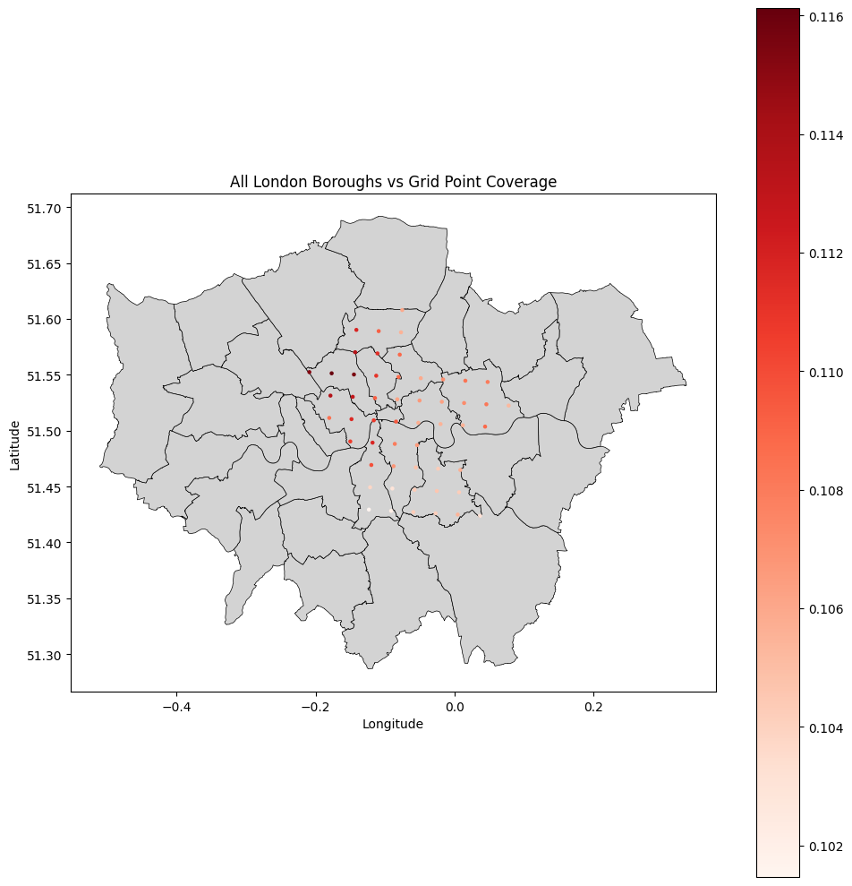

```python
# Visualise ALL boroughs with grid points — before filtering
fig, ax = plt.subplots(figsize=(10, 10))
boroughs.plot(ax=ax, color='lightgrey', edgecolor='black', linewidth=0.5)
grid_gdf.plot(ax=ax, column='nrr95p', cmap='Reds', markersize=5, legend=True)
ax.set_title('All London Boroughs vs Grid Point Coverage')
ax.set_xlabel('Longitude')
ax.set_ylabel('Latitude')
plt.tight_layout()
plt.show()
```

**Notice:** The grid data doesn't cover the entire Greater London area — outer boroughs have no data. We need to filter our borough boundaries to only those that actually contain grid points, otherwise we'd have boroughs with no precipitation data in our final dataset.

```python
# Filter to boroughs that actually contain grid points
boroughs_with_data = gpd.sjoin(
    boroughs, grid_gdf, how="inner", predicate="intersects"
).drop_duplicates(subset=[boroughs.geometry.name])

# Keep only the original borough columns (sjoin adds the point columns)
boroughs_with_data = boroughs_with_data[boroughs.columns]

print(f"Boroughs with data coverage: {len(boroughs_with_data)} / {len(boroughs)}")
```

```
Boroughs with data coverage: 11 / 33
```

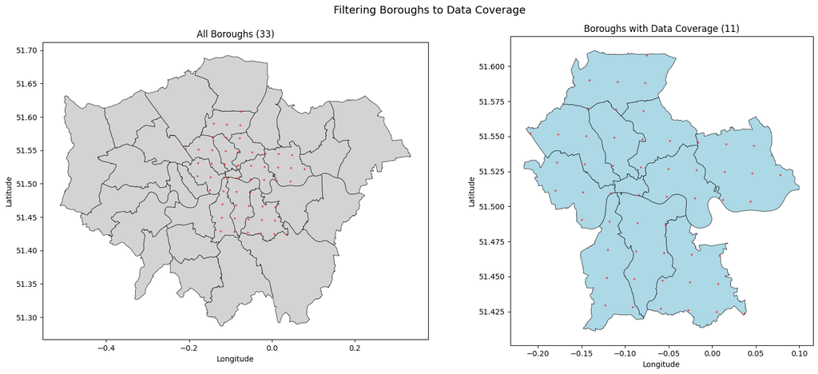

```python
# Visualise the result — filtered boroughs only
fig, axes = plt.subplots(1, 2, figsize=(16, 7))

# Left: all boroughs
boroughs.plot(ax=axes[0], color='lightgrey', edgecolor='black', linewidth=0.5)
grid_gdf.plot(ax=axes[0], color='red', markersize=3, alpha=0.5)
axes[0].set_title(f'All Boroughs ({len(boroughs)})')

# Right: filtered boroughs
boroughs_with_data.plot(ax=axes[1], color='lightblue', edgecolor='black', linewidth=0.5)
grid_gdf.plot(ax=axes[1], color='red', markersize=3, alpha=0.5)
axes[1].set_title(f'Boroughs with Data Coverage ({len(boroughs_with_data)})')

for ax in axes:
    ax.set_xlabel('Longitude')
    ax.set_ylabel('Latitude')

plt.suptitle('Filtering Boroughs to Data Coverage', fontsize=14)
plt.tight_layout()
plt.show()
```

```python
# Interactive map — zoom in to see how grid points overlap borough boundaries
m = boroughs_with_data.explore(color='lightblue', tooltip='name', name='Boroughs')
grid_gdf.explore(m=m, column='nrr95p', cmap='Reds', marker_kwds={'radius': 4}, name='Grid Points')
m
```

Make this Notebook Trusted to load map: File -> Trust Notebook

[interactive chart not shown]

### Memory Management: Why We Explicitly Delete Large Objects

Before moving on, it is worth pausing on **memory management**, because for large spatiotemporal workflows this is often the difference between a notebook that runs smoothly and one that crashes.

#### The problem

When we work with large datasets, we create many big Python objects along the way:

- `ds`, `ds_year` — xarray datasets loaded from NetCDF
- `ds_clean`, `ds_year_clean` — cleaned / reshaped intermediate datasets
- `agg`, `agg_year` — aggregation results
- `agg_df`, `agg_year_df` — pandas tables for export
- `dfs` and `df_all` — concatenated yearly outputs
- exploratory objects such as `df_sample`, `grid_gdf`, `annual_mean`, `summer_mean`

Each of these names points to some object in memory. If we keep references to objects we no longer need, memory usage grows. In a loop over many years, that can eventually lead to slowdowns or even a `MemoryError`.

#### How memory management works in CPython

In CPython, memory management has **two layers**:

1. **Reference counting**  
   Every object keeps track of how many active references point to it.  
   When that count drops to zero, the object can usually be reclaimed immediately.
2. **Cyclic garbage collection**  
   Some objects can reference each other in a cycle, so their reference counts never reach zero even though the program no longer needs them.  
   Python’s garbage collector periodically looks for these unreachable cycles and frees them.

So when we write:

```
del ds_year, ds_year_clean, agg_year, agg_year_df
gc.collect()
```

we are doing two things:

- `del ...` removes the **names** from the notebook namespace
- `gc.collect()` asks Python to immediately run a garbage-collection pass for unreachable cyclic objects

#### Important idea: `del` removes the name, not magically the bytes

For example, in this notebook:

- after aggregation, `ds_year`, `ds_year_clean`, `agg_year`, and `agg_year_df` are no longer needed for the next year
- after concatenation, `dfs` is no longer needed once `df_all` exists
- after the exploratory section, objects like `df_sample`, `grid_means`, `grid_gdf`, `one_day`, `annual_mean`, `summer`, and `summer_mean` are just taking up RAM

Deleting those names tells Python: *we are done with these objects from our side*.

If nothing else still references them, they become reclaimable.

#### What the garbage collector is doing

Conceptually, the garbage collector asks:

> “Which objects are still reachable from the live program, and which are no longer reachable?”

Objects still reachable through active variables, containers, or object attributes stay alive.

Objects that are no longer reachable can be collected.

In notebook terms:

- if `df_all` points to the final combined table, that object must stay alive
- if `dfs` has been deleted and nothing else points to those list elements anymore, those intermediate references can disappear
- if a chain of objects still references each other internally, but nothing in the notebook can reach them anymore, cyclic GC can reclaim them

#### Why?

The critical section is the yearly loop:

```
for year in YEARS:
    ...
    ds_year = xr.open_dataset(...)
    ds_year_clean = ...
    agg_year = ...
    agg_year_df = ...
    ...
    del ds_year, ds_year_clean, agg_year, agg_year_df
    gc.collect()
```

Without the cleanup step, each iteration risks leaving behind large intermediate objects. Even if each year is manageable on its own, 19 years of leftovers are not.

The pattern is:

```
load -> process -> save -> delete references -> collect
```

That is one of the simplest and most effective ways to keep RAM usage bounded.

#### What we can do in Python with `gc`

Python exposes the garbage collector through the built-in `gc` module.

Useful operations include:

- `gc.collect()` Run garbage collection immediately
- `gc.get_count()` See the current collection counters
- `gc.get_threshold()` See the thresholds that control when automatic GC runs
- `gc.get_stats()` Inspect collection statistics
- `gc.set_debug(...)` Turn on debugging output for GC activity
- `gc.disable()` / `gc.enable()` Temporarily disable or re-enable automatic cyclic GC

In practice, for data workflows like this notebook, the most useful pattern is usually still:

```
del large_object_1, large_object_2
gc.collect()
```

#### A practical caution

Garbage collection helps manage **Python objects**, but memory behaviour is not always identical to what you see in a system monitor.

Python uses its own memory manager and allocators internally, and a full collection may clear some internal free lists, but freed memory is not guaranteed to appear as an immediate drop in OS-level memory usage.

So the real goal is not “make RAM instantly look empty” — it is:

- reduce the number of live Python objects
- avoid carrying unnecessary intermediates
- keep long loops stable
- prevent avoidable memory pressure

## Aggregation

### The Problem

We need to go from **grid cells → borough-level values**. But grid cells don't align with borough boundaries — a single 2 km cell can span multiple boroughs. There are several approaches:

| Method | Description | Trade-off |
| --- | --- | --- |
| **Point-in-polygon** | Assign each grid centre to the polygon it falls in | Simple, but ignores that a 2 km cell covers area across borders |
| **Nearest neighbour** | Assign polygon the value of the nearest grid point | Fast, but same problem — no partial overlap |
| **Area-weighted** | Weight each grid cell's contribution by how much it overlaps a polygon | Accounts for partial overlaps; the standard approach for climate data |
| **Population-weighted** | Weight by population density within each cell-polygon intersection | Better for human impact studies (e.g., "how many *people* are exposed?") |
| **Economic-weighted** | Weight by economic activity or asset values | Used in damage assessment and insurance applications |

No single method is "correct" — **the choice should match your research question.** For exposure assessment, population-weighted is often preferred. For physical hazard characterisation, area-weighted is standard. For damage estimation, economic-weighted may be more appropriate.

Today we'll use **area-weighted aggregation** with `xagg`, which computes fractional overlap weights between grid cells and polygons.

### Running xagg on a Single Year

Let's first understand the process with one file before we scale up.

```python
# --- Step 1: Prepare the xarray Dataset ---
# xagg needs an xarray Dataset with latitude and longitude as coordinate dimensions

# Load raw data
ds = xr.open_dataset(DATA_DIR / "ldn_tp_2018.nc")

# Clean the grid natively in xarray
ds_clean = (
    ds
    .stack(point=['rlat', 'rlon'])               # 1. Flatten the 2D grid into a 1D list of points
    .dropna(dim='point', subset=['nrr95p'])      # 2. Drop the individual NaN points
    .set_index(point=['latitude', 'longitude'])  # 3. Swap the index from rlat/rlon to actual lat/lon
    .unstack('point')                            # 4. Reshape back into a spatial grid
)

# Clean up leftover coordinate variables if necessary
if 'rlat' in ds_clean or 'rlon' in ds_clean:
    ds_clean = ds_clean.drop_vars(['rlat', 'rlon'], errors='ignore')

ds_clean
```

```
<xarray.Dataset> Size: 8MB
Dimensions:    (latitude: 53, longitude: 53, time: 365)
Coordinates:
  * latitude   (latitude) float64 424B 51.42 51.42 51.43 ... 51.59 51.59 51.61
  * longitude  (longitude) float64 424B -0.2089 -0.1803 ... 0.0478 0.07803
  * time       (time) datetime64[ns] 3kB 2018-01-01 2018-01-02 ... 2018-12-31
Data variables:
    nrr95p     (time, latitude, longitude) float64 8MB nan nan nan ... nan nan
Attributes:
    institution:  Fondazione Centro Euro-Mediterraneo sui Cambiamenti Climati...
    experiment:   ERA5-2km i.e., cclm-sp_2.4_terra_urb_2.3.1 simulation (0.02...
    references:   http//www.clm-community.eu, http://www.cmcc.it
    Conventions:  CF-1.6
    contacts:     copernicus-support@ecmwf.int
    contract:     C3S_430 Sectoral Information System to support Disaster Ris...
    title:        Extreme precipitation indicators for Europe and European ci...
    author:       Fondazione Centro Euro-Mediterraneo sui Cambiamenti Climati...
    version:      version 1.0
```

```python
# --- Step 2: Compute pixel-polygon overlap weights ---
# This tells xagg what fraction of each grid cell falls in each borough.
# This only needs to be computed ONCE — the grid and boundaries don't change between years.

weightmap = xagg.pixel_overlaps(ds_clean, boroughs_with_data, subset_bbox=True)
print("Weightmap computed — this will be reused for all years.")

# --- Step 3: Aggregate ---
# This applies the weights to compute area-weighted means per borough per day

agg = xagg.aggregate(ds_clean, weightmap)
agg_df = agg.to_dataframe().reset_index()

print(f"Aggregated shape: {agg_df.shape}")
agg_df.head()
```

```
creating polygons for each pixel...
lat/lon bounds not found in dataset; they will be created.
Found 8 break(s)/jump(s) in lat (i.e., grid doesn't cover whole planet); replacing grid cell width(s) with preceding grid cell width(s) at breakpoint.
Found 7 break(s)/jump(s) in lon (i.e., grid doesn't cover whole planet); replacing grid cell width(s) with preceding grid cell width(s) at breakpoint.
calculating overlaps between pixels and output polygons...
success!
Weightmap computed — this will be reused for all years.
aggregating nrr95p...
all variables aggregated to polygons!
Aggregated shape: (4015, 10)
```

|  | poly_idx | time | objectid | name | gss_code | hectares | nonld_area | ons_inner | sub_2011 | nrr95p |
| --- | --- | --- | --- | --- | --- | --- | --- | --- | --- | --- |
| 0 | 0 | 2018-01-01 | 11 | Lewisham | E09000023 | 3531.7060 | 16.7950 | T | East | 0.0389 |
| 1 | 0 | 2018-01-02 | 11 | Lewisham | E09000023 | 3531.7060 | 16.7950 | T | East | 0.4279 |
| 2 | 0 | 2018-01-03 | 11 | Lewisham | E09000023 | 3531.7060 | 16.7950 | T | East | 0.0942 |
| 3 | 0 | 2018-01-04 | 11 | Lewisham | E09000023 | 3531.7060 | 16.7950 | T | East | 0.5390 |
| 4 | 0 | 2018-01-05 | 11 | Lewisham | E09000023 | 3531.7060 | 16.7950 | T | East | 0.0578 |

### Visualising the Aggregated Result

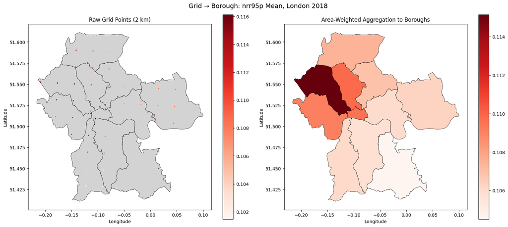

```python
# Compute borough-level annual means for plotting
agg_annual = agg_df.groupby('name')['nrr95p'].mean().reset_index()

# Merge with geometry for mapping
agg_gdf = boroughs_with_data.merge(agg_annual, on='name', how='left')

fig, axes = plt.subplots(1, 2, figsize=(16, 7))

# Left: raw grid points
_grid = ds.to_dataframe().reset_index().dropna().groupby(['latitude','longitude'])['nrr95p'].mean().reset_index()
_grid_gdf = gpd.GeoDataFrame(_grid, geometry=gpd.points_from_xy(_grid.longitude, _grid.latitude), crs='EPSG:4326')
boroughs_with_data.plot(ax=axes[0], color='lightgrey', edgecolor='black', linewidth=0.5)
_grid_gdf.plot(ax=axes[0], column='nrr95p', cmap='Reds', markersize=3, legend=True)
axes[0].set_title('Raw Grid Points (2 km)')

# Right: aggregated to boroughs
agg_gdf.plot(ax=axes[1], column='nrr95p', cmap='Reds', edgecolor='black', linewidth=0.5, legend=True)
axes[1].set_title('Area-Weighted Aggregation to Boroughs')

for ax in axes:
    ax.set_xlabel('Longitude')
    ax.set_ylabel('Latitude')

plt.suptitle('Grid → Borough: nrr95p Mean, London 2018', fontsize=14)
plt.tight_layout()
plt.show()
```

### Aggregation Pitfalls

Spatial aggregation is not neutral — results depend on the units and resolution used.

- **MAUP:** changing boundary size or shape can change the pattern
- **Resolution mismatch:** small boroughs may only overlap a few grid cells
- **Edge effects:** partial overlaps can affect boundary areas

**Takeaway:** aggregation is a modelling choice, so be explicit about boundaries, support, and limitations.

```python
# Check: how many grid cells contribute to each borough?
# This helps assess reliability of the aggregation

_grid_check = ds.to_dataframe().reset_index().dropna().groupby(['latitude','longitude']).first().reset_index()
_grid_check_gdf = gpd.GeoDataFrame(
    _grid_check, geometry=gpd.points_from_xy(_grid_check.longitude, _grid_check.latitude), crs='EPSG:4326'
)

cells_per_borough = (
    gpd.sjoin(boroughs_with_data[['name','geometry']], _grid_check_gdf, how='left', predicate='intersects')
    .groupby('name')
    .size()
    .reset_index(name='n_grid_cells')
    .sort_values('n_grid_cells')
)

print("Grid cells per borough (fewest first):")
print(cells_per_borough.to_string(index=False))
print(f"\nBoroughs with ≤ 3 grid cells: {(cells_per_borough['n_grid_cells'] <= 3).sum()}")
print("(Results for these boroughs should be interpreted with caution.)")

del _grid_check, _grid_check_gdf
gc.collect()
```

```
Grid cells per borough (fewest first):
          name  n_grid_cells
City of London             1
       Hackney             3
     Islington             3
        Camden             4
 Tower Hamlets             4
       Lambeth             5
     Southwark             5
   Westminster             5
      Haringey             6
        Newham             8
      Lewisham             9

Boroughs with ≤ 3 grid cells: 3
(Results for these boroughs should be interpreted with caution.)
```

```
24643
```

### A Design Principle: Separate Geometry from Data

When working with large spatiotemporal datasets, carrying geometry columns everywhere is **expensive**. A GeoDataFrame with millions of rows and complex polygon geometries uses far more memory than the same data without geometry.

**The pattern:**

1. **Aggregated data** → save as a lightweight table (parquet) with just the borough *name*, date, and values. **No geometry.**
2. **Geometry lookup** → keep a small, separate GeoDataFrame of borough boundaries that you merge back *only when you need to map*.

This way, you're never carrying geometry through millions of rows of data processing. You only pay the geometry cost when visualising.

```python
# Prepare the clean output — only name, time, and value columns
output_cols = ['name', 'time', 'nrr95p']
agg_clean = agg_df[output_cols].copy()

print(f"Clean output shape: {agg_clean.shape}")
print(f"Memory: {agg_clean.memory_usage(deep=True).sum() / 1e6:.2f} MB")
agg_clean.head()

# Save the borough geometry lookup separately — you only need this once
borough_lookup = boroughs_with_data[['name', 'geometry']].copy()
borough_lookup.to_file(GEO_DIR / 'borough_lookup.gpkg', driver='GPKG')

print(f"Borough lookup: {len(borough_lookup)} rows, saved to borough_lookup.gpkg")
print("This small file is all you need to rejoin geometry later.")

# Clean up  objects
del ds, ds_clean, agg, agg_df, agg_annual, agg_gdf, agg_clean
del _grid, _grid_gdf, cells_per_borough
gc.collect()
print("Memory freed.")
```

```
Clean output shape: (4015, 3)
Memory: 0.30 MB
Borough lookup: 11 rows, saved to borough_lookup.gpkg
This small file is all you need to rejoin geometry later.
Memory freed.
```

## Efficient Workflows: Loops, Memory, and Parquet

We just processed **one year**. Now we need to do this for **all 19 years** (2000–2018).

### The Pattern: Process → Save → Free Memory

When processing many large files, the key pattern is:

```
for each file:
    1. Load data
    2. Process (clean, aggregate)
    3. Save result to disk (parquet)
    4. Delete objects from memory (del)
    5. Force garbage collection (gc.collect())
```

This ensures you never hold more than one year's worth of data in memory at a time. Without steps 4–5, Python may keep old objects in memory, and after processing a few years you could run out of RAM.

### Why Parquet?

You're probably used to CSV files. **Parquet** is a columnar storage format that is:

- **Smaller on disk** — typically 3–10× smaller than CSV (columnar compression)
- **Faster to read** — especially for large datasets and column subsets
- **Type-preserving** — dates stay as dates, floats stay as floats (no re-parsing on load)

Let's see the difference. We'll use the **raw grid data** (before aggregation) to get a meaningful file size comparison:

```python
# CSV vs Parquet comparison — using the raw grid data for a meaningful test
ds_demo = xr.open_dataset(DATA_DIR / "ldn_tp_2018.nc")
df_demo = ds_demo.to_dataframe().reset_index().dropna(subset=['nrr95p'])

print(f"Test dataset: {len(df_demo):,} rows × {len(df_demo.columns)} columns")
print(f"In-memory size: {df_demo.memory_usage(deep=True).sum() / 1e6:.1f} MB")

# Save as CSV
df_demo.to_csv(OUTPUT_DIR / 'demo_raw.csv', index=False)

# Save as Parquet
df_demo.to_parquet(OUTPUT_DIR / 'demo_raw.parquet', index=False)
```

```
Test dataset: 19,345 rows × 6 columns
In-memory size: 1.1 MB
```

```python
csv_size = os.path.getsize(OUTPUT_DIR / 'demo_raw.csv') / 1e6
pq_size = os.path.getsize(OUTPUT_DIR / 'demo_raw.parquet') / 1e6

# Time CSV read (average of 3 runs)
csv_times = []
for _ in range(3):
    t0 = time.time()
    _ = pd.read_csv(OUTPUT_DIR / 'demo_raw.csv')
    csv_times.append(time.time() - t0)
csv_time = np.mean(csv_times)

# Time Parquet read (average of 3 runs)
pq_times = []
for _ in range(3):
    t0 = time.time()
    _ = pd.read_parquet(OUTPUT_DIR / 'demo_raw.parquet')
    pq_times.append(time.time() - t0)
pq_time = np.mean(pq_times)

print(f"{'Format':<10} {'Size (MB)':<12} {'Read Time (s)':<15}")
print(f"{'-'*37}")
print(f"{'CSV':<10} {csv_size:<12.2f} {csv_time:<15.4f}")
print(f"{'Parquet':<10} {pq_size:<12.2f} {pq_time:<15.4f}")
print(f"\nParquet is {csv_size/pq_size:.1f}× smaller and {(csv_time* 1000)/(pq_time* 1000):.1f}× faster to read.")
```

```
Format     Size (MB)    Read Time (s)
-------------------------------------
CSV        1.97         0.0078
Parquet    0.14         0.0014

Parquet is 14.2× smaller and 5.4× faster to read.
```

```python
import time
import pandas as pd
from statistics import mean

def bench(fn, n=20):
    times = []
    for _ in range(n):
        t0 = time.perf_counter()
        fn()
        times.append(time.perf_counter() - t0)
    return mean(times)

csv_time = bench(lambda: pd.read_csv(OUTPUT_DIR / "demo_raw.csv"))
parquet_time = bench(lambda: pd.read_parquet(OUTPUT_DIR / "demo_raw.parquet"))

print(f"CSV read time: {csv_time:.4f} s")
print(f"Parquet read time: {parquet_time:.4f} s")
```

```
CSV read time: 0.0076 s
Parquet read time: 0.0007 s
```

```python
# Clean up demo files
os.remove(OUTPUT_DIR / 'demo_raw.csv')
os.remove(OUTPUT_DIR / 'demo_raw.parquet')
del ds_demo, df_demo
gc.collect()
```

```
12
```